# R_assign1.md

First I will load all the required packages.

```r
library(janitor)
library(tidyverse)
library(plyr)
```

```r
library(dplyr )
library(ggplot2)
library(reshape2)
```

After loading the required packages, read the required files into R.

```r
fang<-read_tsv("https://raw.githubusercontent.com/EEOB-BioData/BCB546-Spring2022/main/assignments/UNIX_Assignment/fang_et_al_genotypes.txt")
view(fang)
snp<-read_tsv("https://raw.githubusercontent.com/EEOB-BioData/BCB546-Spring2022/main/assignments/UNIX_Assignment/snp_position.txt")
view(snp)
```

Now I have both snp and fang files loaded and stored in objects in r.

```r
fang
```

```
## # A tibble: 2,782 × 986
##    Sample_ID JG_OTU  Group abph1.20 abph1.22 ae1.3 ae1.4 ae1.5 an1.4 ba1.6 ba1.9
##    <chr>     <chr>   <chr> <chr>    <chr>    <chr> <chr> <chr> <chr> <chr> <chr>
##  1 SL-15     T-aust… TRIPS ?/?      ?/?      T/T   G/G   T/T   C/C   ?/?   G/G
##  2 SL-16     T-aust… TRIPS ?/?      ?/?      T/T   ?/?   T/T   C/C   A/G   G/G
##  3 SL-11     T-brav… TRIPS ?/?      ?/?      T/T   G/G   T/T   ?/?   G/G   G/G
##  4 SL-12     T-brav… TRIPS ?/?      ?/?      T/T   G/G   T/T   C/C   G/G   G/G
##  5 SL-18     T-cund  TRIPS ?/?      ?/?      T/T   G/G   T/T   C/C   ?/?   G/G
##  6 SL-2      T-dact… TRIPS ?/?      ?/?      T/T   G/G   T/T   C/C   A/G   G/G
##  7 SL-4      T-dact… TRIPS ?/?      ?/?      T/T   G/G   T/T   C/C   G/G   G/G
##  8 SL-6      T-dact… TRIPS ?/?      ?/?      T/T   G/G   T/T   C/C   ?/?   G/G
##  9 SL-7      T-dact… TRIPS ?/?      ?/?      T/T   G/G   T/T   C/C   G/G   G/G
## 10 SL-5      T-dact… TRIPS ?/?      ?/?      T/T   G/G   T/T   C/C   ?/?   G/G
## # … with 2,772 more rows, and 975 more variables: bt2.5 <chr>, bt2.7 <chr>,
## #   bt2.8 <chr>, Fea2.1 <chr>, Fea2.5 <chr>, id1.3 <chr>, lg2.11 <chr>,
## #   lg2.2 <chr>, pbf1.1 <chr>, pbf1.2 <chr>, pbf1.3 <chr>, pbf1.5 <chr>,
## #   pbf1.6 <chr>, pbf1.7 <chr>, pbf1.8 <chr>, PZA00003.11 <chr>,
## #   PZA00004.2 <chr>, PZA00005.8 <chr>, PZA00005.9 <chr>, PZA00006.13 <chr>,
## #   PZA00006.14 <chr>, PZA00008.1 <chr>, PZA00010.5 <chr>, PZA00013.10 <chr>,
## #   PZA00013.11 <chr>, PZA00013.9 <chr>, PZA00015.4 <chr>, PZA00017.1 <chr>, …
```

```r
snp
```

```
## # A tibble: 983 × 15
##    SNP_ID   cdv_marker_id Chromosome Position  alt_pos mult_positions amplicon
##    <chr>            <dbl> <chr>      <chr>     <chr>   <chr>          <chr>
##  1 abph1.20          5976 2          27403404  <NA>    <NA>           abph1
##  2 abph1.22          5978 2          27403892  <NA>    <NA>           abph1
##  3 ae1.3             6605 5          167889790 <NA>    <NA>           ae1
##  4 ae1.4             6606 5          167889682 <NA>    <NA>           ae1
##  5 ae1.5             6607 5          167889821 <NA>    <NA>           ae1
##  6 an1.4             5982 1          240498509 <NA>    <NA>           an1
##  7 ba1.6             3463 3          181362952 <NA>    <NA>           ba1
##  8 ba1.9             3466 3          181362666 <NA>    <NA>           ba1
##  9 bt2.5             5983 4          66290049  <NA>    <NA>           bt2
## 10 bt2.7             5985 4          66290994  <NA>    <NA>           bt2
## # … with 973 more rows, and 8 more variables: cdv_map_feature.name <chr>,
## #   gene <chr>, candidate/random <chr>, Genaissance_daa_id <dbl>,
## #   Sequenom_daa_id <dbl>, count_amplicons <dbl>, count_cmf <dbl>,
## #   count_gene <dbl>
```

This tells me that fang is a 2782X986 tibble and snp is a 983x15 tibble. Considerably smaller

```r
object.size(fang) #23.14 MB, or 23124584 bytes
```

```
## 23124584 bytes
```

```r
object.size(snp) #359.384 KB, or 359384 bytes
```

```
## 359384 bytes
```

```r
fangcols<-colnames(fang)
snpcols<- colnames(snp)
```

```r
maize <- filter(fang, `Group` %in% c('ZMMLR','ZMMMR','ZMMIL'))
teosinte <- filter(fang, `Group` %in% c('ZMPBA','ZMPIL','ZMPJA'))
```

This has created subsets of the maize and teosinte values.

```r
view(teosinte)
```

Just checking, it looks good so far. Next I need to transcribe my teosinte and maize files so that they rows and columns run in the other direction.

```r
transteo <- t(teosinte)
transmaize <- t(maize)
```

Next I will cut my SNP file so that I have the columns SNP_ID, Chromosome, and Position.

```r
snpsnip <- select(snp, c('SNP_ID','Chromosome','Position'))
view(snpsnip)
```

Looks good! I need to remove a few unnecessary rows from my files, make headers, and check my dimensions.

```r
trimteo <- row_to_names(transteo, 3, remove_row = TRUE, remove_rows_above = TRUE)
trimmaize <- row_to_names(transmaize, 3, remove_row = TRUE, remove_rows_above = TRUE)
summary(trimteo)
```

[output not shown]

[output cut: 921 more lines]

```
##  Length:983         Length:983         Length:983         Length:983
##  Class :character   Class :character   Class :character   Class :character
##  Mode  :character   Mode  :character   Mode  :character   Mode  :character
##     ZMPIL              ZMPIL              ZMPIL              ZMPIL
##  Length:983         Length:983         Length:983         Length:983
##  Class :character   Class :character   Class :character   Class :character
##  Mode  :character   Mode  :character   Mode  :character   Mode  :character
##     ZMPIL              ZMPIL              ZMPIL              ZMPIL
##  Length:983         Length:983         Length:983         Length:983
##  Class :character   Class :character   Class :character   Class :character
##  Mode  :character   Mode  :character   Mode  :character   Mode  :character
##     ZMPIL              ZMPIL              ZMPIL
##  Length:983         Length:983         Length:983
##  Class :character   Class :character   Class :character
##  Mode  :character   Mode  :character   Mode  :character
```

```r
summary(snpsnip)
```

```
##     SNP_ID           Chromosome          Position
##  Length:983         Length:983         Length:983
##  Class :character   Class :character   Class :character
##  Mode  :character   Mode  :character   Mode  :character
```

My dataframes are equal length and all cleaned up, so now I will join by the common column.

```r
teosnp <- cbind(snpsnip,trimteo)
teosintesnp1<-subset(teosnp, Chromosome!="unknown" & Chromosome!="multiple")
teosintesnp<-subset(teosintesnp1, Position!="multiple")
maisnp <- cbind(snpsnip,trimmaize)
maizesnp1<-subset(maisnp, Chromosome!="unknown" & Chromosome!="multiple")
maizesnp<-subset(maizesnp1, Position!="multiple")
```

Now the files are bound together, with the first three columns coming from my snp file. I have also removed the entries that had unknown and multiple chromosomes. I am now ready to move to the next step. Now I need a file with missing data encoded by “?” and one with missing data encoded by “-”. My file already has missing data encoded by “?”. Next step is to sort by position values for my existing files. After this point, I will make another file with decreasing position values and “-” in place of missing values.

```r
maizesnp$Position = as.numeric(as.character(maizesnp$Position))
is.numeric(maizesnp$Position)
```

```
## [1] TRUE
```

```r
maize_quest <- maizesnp[order(maizesnp$Position) ,]
teosintesnp$Position = as.numeric(as.character(teosintesnp$Position))
is.numeric(teosintesnp$Position)
```

```
## [1] TRUE
```

```r
teo_quest <- teosintesnp[order(teosintesnp$Position) ,]
```

I had to convert the Position column from character to numeric in order to sort numerically. The next step is to reverse sort by Position and replace ? with -.

```r
maize_dash1 <- data.frame(lapply(maize_quest, gsub, pattern = "[?]", replacement = "-"))
teo_dash1 <- data.frame(lapply(teo_quest, gsub, pattern = "[?]", replacement = "-"))
maize_dash1$Position = as.numeric(as.character(maize_dash1$Position))
teo_dash1$Position = as.numeric(as.character(teo_dash1$Position))
maize_dash <-maize_dash1[order(rev(maize_dash1$Position)),]
teo_dash <-teo_dash1[order(rev(teo_dash1$Position)),]
maize_quest$Position = as.numeric(as.character(maize_quest$Position))
teo_quest$Position = as.numeric(as.character(teo_quest$Position))
```

Now I’m ready to split into separate files for maize and teosinte data. I need chr 1-10 of maize and teo, ascending position (maize_quest, teo_quest) and also chr 1-10 of maize and teo, descending position (maize_dash, teo_dash).

```r
maize_increase_1<-subset(maize_quest, Chromosome=="1")
write.csv(maize_increase_1,"/Users/gracecarey/Documents/GitHub/r_assign_546//maize_inc_1.csv")
#
maize_increase_2<-subset(maize_quest, Chromosome=="2")
write.csv(maize_increase_2,"/Users/gracecarey/Documents/GitHub/r_assign_546//maize_inc_2.csv")
#
maize_increase_3<-subset(maize_quest, Chromosome=="3")
write.csv(maize_increase_3,"/Users/gracecarey/Documents/GitHub/r_assign_546//maize_inc_3.csv")
#
maize_increase_4<-subset(maize_quest, Chromosome=="4")
write.csv(maize_increase_4,"/Users/gracecarey/Documents/GitHub/r_assign_546//maize_inc_4.csv")
#
maize_increase_5<-subset(maize_quest, Chromosome=="5")
write.csv(maize_increase_5,"/Users/gracecarey/Documents/GitHub/r_assign_546//maize_inc_5.csv")
#
maize_increase_6<-subset(maize_quest, Chromosome=="6")
write.csv(maize_increase_6,"/Users/gracecarey/Documents/GitHub/r_assign_546//maize_inc_6.csv")
#
maize_increase_7<-subset(maize_quest, Chromosome=="7")
write.csv(maize_increase_7,"/Users/gracecarey/Documents/GitHub/r_assign_546//maize_inc_7.csv")
#
maize_increase_8<-subset(maize_quest, Chromosome=="8")
write.csv(maize_increase_8,"/Users/gracecarey/Documents/GitHub/r_assign_546//maize_inc_8.csv")
#
maize_increase_9<-subset(maize_quest, Chromosome=="9")
write.csv(maize_increase_9,"/Users/gracecarey/Documents/GitHub/r_assign_546//maize_inc_9.csv")
#
maize_increase_10<-subset(maize_quest, Chromosome=="10")
write.csv(maize_increase_10,"/Users/gracecarey/Documents/GitHub/r_assign_546//maize_inc_10.csv")
#
teo_increase_1<-subset(teo_quest, Chromosome=="1")
write.csv(teo_increase_1,"/Users/gracecarey/Documents/GitHub/r_assign_546//teo_inc_1.csv")
#
teo_increase_2<-subset(teo_quest, Chromosome=="2")
write.csv(teo_increase_2,"/Users/gracecarey/Documents/GitHub/r_assign_546//teo_inc_2.csv")
#
teo_increase_3<-subset(teo_quest, Chromosome=="3")
write.csv(teo_increase_3,"/Users/gracecarey/Documents/GitHub/r_assign_546//teo_inc_3.csv")
#
teo_increase_4<-subset(teo_quest, Chromosome=="4")
write.csv(teo_increase_4,"/Users/gracecarey/Documents/GitHub/r_assign_546//teo_inc_4.csv")
#
teo_increase_5<-subset(teo_quest, Chromosome=="5")
write.csv(teo_increase_5,"/Users/gracecarey/Documents/GitHub/r_assign_546//teo_inc_5.csv")
#
teo_increase_6<-subset(teo_quest, Chromosome=="6")
write.csv(teo_increase_6,"/Users/gracecarey/Documents/GitHub/r_assign_546//teo_inc_6.csv")
#
teo_increase_7<-subset(teo_quest, Chromosome=="7")
write.csv(teo_increase_7,"/Users/gracecarey/Documents/GitHub/r_assign_546//teo_inc_7.csv")
#
teo_increase_8<-subset(teo_quest, Chromosome=="8")
write.csv(teo_increase_8,"/Users/gracecarey/Documents/GitHub/r_assign_546//teo_inc_8.csv")
#
teo_increase_9<-subset(teo_quest, Chromosome=="9")
write.csv(teo_increase_9,"/Users/gracecarey/Documents/GitHub/r_assign_546//teo_inc_9.csv")
#
teo_increase_10<-subset(teo_quest, Chromosome=="10")
write.csv(teo_increase_10,"/Users/gracecarey/Documents/GitHub/r_assign_546//teo_inc_10.csv")
#
maize_decrease_1<-subset(maize_dash, Chromosome=="1")
write.csv(maize_decrease_1,"/Users/gracecarey/Documents/GitHub/r_assign_546//maize_dec_1.csv")
#
maize_decrease_2<-subset(maize_dash, Chromosome=="2")
write.csv(maize_decrease_2,"/Users/gracecarey/Documents/GitHub/r_assign_546//maize_dec_2.csv")
#
maize_decrease_3<-subset(maize_dash, Chromosome=="3")
write.csv(maize_decrease_3,"/Users/gracecarey/Documents/GitHub/r_assign_546//maize_dec_3.csv")
#
maize_decrease_4<-subset(maize_dash, Chromosome=="4")
write.csv(maize_decrease_4,"/Users/gracecarey/Documents/GitHub/r_assign_546//maize_dec_4.csv")
#
maize_decrease_5<-subset(maize_dash, Chromosome=="5")
write.csv(maize_decrease_5,"/Users/gracecarey/Documents/GitHub/r_assign_546//maize_dec_5.csv")
#
maize_decrease_6<-subset(maize_dash, Chromosome=="6")
write.csv(maize_decrease_6,"/Users/gracecarey/Documents/GitHub/r_assign_546//maize_dec_6.csv")
#
maize_decrease_7<-subset(maize_dash, Chromosome=="7")
write.csv(maize_decrease_7,"/Users/gracecarey/Documents/GitHub/r_assign_546//maize_dec_7.csv")
#
maize_decrease_8<-subset(maize_dash, Chromosome=="8")
write.csv(maize_decrease_8,"/Users/gracecarey/Documents/GitHub/r_assign_546//maize_dec_8.csv")
#
maize_decrease_9<-subset(maize_dash, Chromosome=="9")
write.csv(maize_decrease_9,"/Users/gracecarey/Documents/GitHub/r_assign_546//maize_dec_9.csv")
#
maize_decrease_10<-subset(maize_dash, Chromosome=="10")
write.csv(maize_decrease_10,"/Users/gracecarey/Documents/GitHub/r_assign_546//maize_dec_10.csv")
#
teo_decrease_1<-subset(teo_dash, Chromosome=="1")
write.csv(teo_decrease_1,"/Users/gracecarey/Documents/GitHub/r_assign_546//teo_dec_1.csv")
#
teo_decrease_2<-subset(teo_dash, Chromosome=="2")
write.csv(teo_decrease_2,"/Users/gracecarey/Documents/GitHub/r_assign_546//teo_dec_2.csv")
#
teo_decrease_3<-subset(teo_dash, Chromosome=="3")
write.csv(teo_decrease_3,"/Users/gracecarey/Documents/GitHub/r_assign_546//teo_dec_3.csv")
#
teo_decrease_4<-subset(teo_dash, Chromosome=="4")
write.csv(teo_decrease_4,"/Users/gracecarey/Documents/GitHub/r_assign_546//teo_dec_4.csv")
#
teo_decrease_5<-subset(teo_dash, Chromosome=="5")
write.csv(teo_decrease_5,"/Users/gracecarey/Documents/GitHub/r_assign_546//teo_dec_5.csv")
#
teo_decrease_6<-subset(teo_dash, Chromosome=="6")
write.csv(teo_decrease_6,"/Users/gracecarey/Documents/GitHub/r_assign_546//teo_dec_6.csv")
#
teo_decrease_7<-subset(teo_dash, Chromosome=="7")
write.csv(teo_decrease_7,"/Users/gracecarey/Documents/GitHub/r_assign_546//teo_dec_7.csv")
#
teo_decrease_8<-subset(teo_dash, Chromosome=="8")
write.csv(teo_decrease_8,"/Users/gracecarey/Documents/GitHub/r_assign_546//teo_dec_8.csv")
#
teo_decrease_9<-subset(teo_dash, Chromosome=="9")
write.csv(teo_decrease_9,"/Users/gracecarey/Documents/GitHub/r_assign_546//teo_dec_9.csv")
#
teo_decrease_10<-subset(teo_dash, Chromosome=="10")
write.csv(teo_decrease_10,"/Users/gracecarey/Documents/GitHub/r_assign_546//teo_dec_10.csv")
#
```

Now on to visualization!

To do these steps, I will use the “maize_dash” and “teo_dash” files since order does not matter. I choose the dash files because the question mark appears to mess up a lot of R codes.

```r
maize_df <- maize_dash
teo_df <- teo_dash
maize_df$Position = as.character(as.double(maize_df$Position))
teo_df$Position = as.character(as.double(teo_df$Position))
maize_df %>% pivot_longer(!Chromosome, names_to = "Position", values_to= "BP", )%>%  {.} -> maize_long
teo_df %>% pivot_longer(!Chromosome, names_to = "Position", values_to= "BP", )%>%  {.} -> teo_long
maize_long$Chromosome = as.numeric(as.character(maize_long$Chromosome))
teo_long$Chromosome = as.numeric(as.character(teo_long$Chromosome))
dim(maize_long)
```

```
## [1] 1478925       3
```

```r
mutate(maize_long, maize_long$Species <- ("Maize"))
```

```
## # A tibble: 1,478,925 × 3
##    Chromosome Position BP
##         <dbl> <chr>    <chr>
##  1          1 SNP_ID   PZA00230.5
##  2          1 Position 298412984
##  3          1 ZMMLR    G/G
##  4          1 ZMMLR.1  G/G
##  5          1 ZMMLR.2  -/-
##  6          1 ZMMLR.3  C/C
##  7          1 ZMMLR.4  C/C
##  8          1 ZMMLR.5  C/C
##  9          1 ZMMLR.6  C/G
## 10          1 ZMMLR.7  C/C
## # … with 1,478,915 more rows
```

```r
maize_long1 <- mutate(maize_long, maize_long$Species==("Maize"))
maize_long%>%
  select(Chromosome, Position) %>%
  mutate(
    Species = "Maize"
  )%>% {.} -> maize_mut
view(maize_mut)
teo_long%>%
  select(Chromosome, Position) %>%
  mutate(
    Species = "Teosinte"
     )%>% {.} -> teo_mut

bind <- bind_rows(maize_mut, teo_mut)
view(bind)
bind%>%
  select(Chromosome, Position,Species) %>%
  mutate(
    Chromnumber = Chromosome
    )%>% {.} -> bind1
```

Now I have the key file to make visualization1 from!

```r
is.numeric(bind1$Chromosome)
```

```
## [1] TRUE
```

```r
bind1$Chromosome = as.character(as.numeric(bind1$Chromosome))
```

And here is the plot which shows distribution of Chromosomes by species:

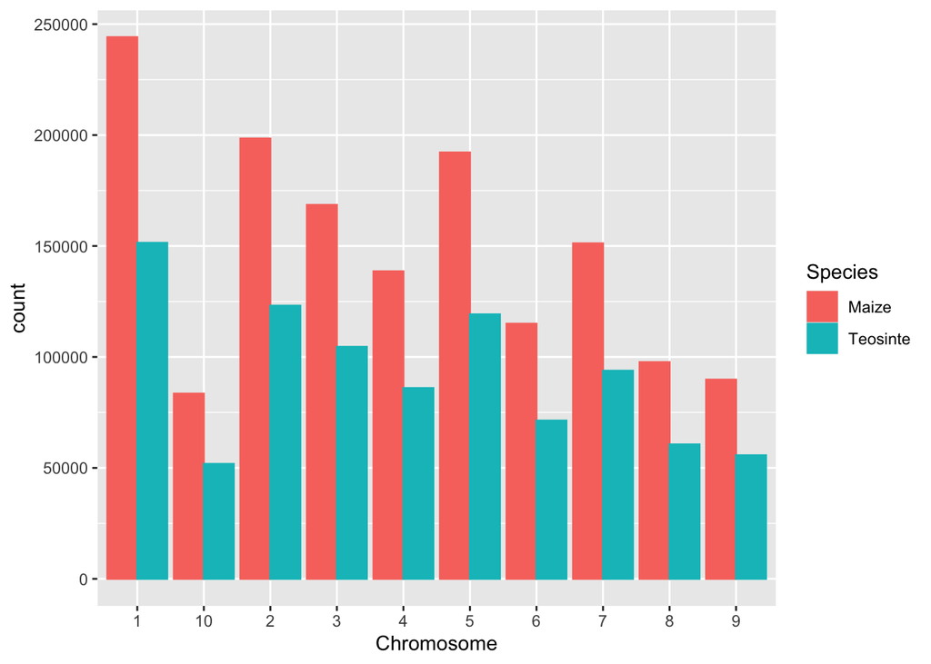

```r
ggplot(bind1, aes(x=Chromosome, fill= Species, color= Species)) + geom_bar(bins=10, position = "dodge")
```

Now I will move on to step two of the Visualization. I will go back to the steps in my code where I split into maize and teosinte, and rerun through using a combined maize+teo Group selection. I will also bind to the trimmed snp file again.

```r
full_mt <- filter(fang, `Group` %in% c('ZMMLR','ZMMMR','ZMMIL','ZMPBA','ZMPIL','ZMPJA'))
#view(full_mt)
trans_full_mt <- t(full_mt)
trimfull <- row_to_names(trans_full_mt, 3, remove_row = TRUE, remove_rows_above = TRUE)
fullsnp <- cbind(snpsnip,trimfull)
trimfull1<-subset(fullsnp, Chromosome!="unknown" & Chromosome!="multiple")
fullsnpcombo<-subset(trimfull1, Position!="multiple")
#view(fullsnpcombo)
```

Now I have one huge file from which to find homozygous and heterozygous samples.

```r
longest_pivot <- pivot_longer(fullsnpcombo, c(2:2524), names_to = "Sample", values_to = "NT")
longest_pivot_trim <- longest_pivot[-c(1,2),]
head(longest_pivot_trim)
```

```
## # A tibble: 6 × 30
##   SNP_ID   ZMMIL.263 ZMMIL.264 ZMMIL.265 ZMMIL.266 ZMMIL.267 ZMMIL.268 ZMMIL.269
##   <chr>    <chr>     <chr>     <chr>     <chr>     <chr>     <chr>     <chr>
## 1 abph1.20 C/C       C/C       C/C       G/G       C/C       C/C       C/C
## 2 abph1.20 C/C       C/C       C/C       G/G       C/C       C/C       C/C
## 3 abph1.20 C/C       C/C       C/C       G/G       C/C       C/C       C/C
## 4 abph1.20 C/C       C/C       C/C       G/G       C/C       C/C       C/C
## 5 abph1.20 C/C       C/C       C/C       G/G       C/C       C/C       C/C
## 6 abph1.20 C/C       C/C       C/C       G/G       C/C       C/C       C/C
## # … with 22 more variables: ZMMIL.270 <chr>, ZMMIL.271 <chr>, ZMMIL.272 <chr>,
## #   ZMMIL.273 <chr>, ZMMIL.274 <chr>, ZMMIL.275 <chr>, ZMMIL.276 <chr>,
## #   ZMMIL.277 <chr>, ZMMIL.278 <chr>, ZMMIL.279 <chr>, ZMMIL.280 <chr>,
## #   ZMMIL.281 <chr>, ZMMIL.282 <chr>, ZMMIL.283 <chr>, ZMMIL.284 <chr>,
## #   ZMMIL.285 <chr>, ZMMIL.286 <chr>, ZMMIL.287 <chr>, ZMMIL.288 <chr>,
## #   ZMMIL.289 <chr>, Sample <chr>, NT <chr>
```

```r
long_df <- longest_pivot_trim
head(long_df)
```

```
## # A tibble: 6 × 30
##   SNP_ID   ZMMIL.263 ZMMIL.264 ZMMIL.265 ZMMIL.266 ZMMIL.267 ZMMIL.268 ZMMIL.269
##   <chr>    <chr>     <chr>     <chr>     <chr>     <chr>     <chr>     <chr>
## 1 abph1.20 C/C       C/C       C/C       G/G       C/C       C/C       C/C
## 2 abph1.20 C/C       C/C       C/C       G/G       C/C       C/C       C/C
## 3 abph1.20 C/C       C/C       C/C       G/G       C/C       C/C       C/C
## 4 abph1.20 C/C       C/C       C/C       G/G       C/C       C/C       C/C
## 5 abph1.20 C/C       C/C       C/C       G/G       C/C       C/C       C/C
## 6 abph1.20 C/C       C/C       C/C       G/G       C/C       C/C       C/C
## # … with 22 more variables: ZMMIL.270 <chr>, ZMMIL.271 <chr>, ZMMIL.272 <chr>,
## #   ZMMIL.273 <chr>, ZMMIL.274 <chr>, ZMMIL.275 <chr>, ZMMIL.276 <chr>,
## #   ZMMIL.277 <chr>, ZMMIL.278 <chr>, ZMMIL.279 <chr>, ZMMIL.280 <chr>,
## #   ZMMIL.281 <chr>, ZMMIL.282 <chr>, ZMMIL.283 <chr>, ZMMIL.284 <chr>,
## #   ZMMIL.285 <chr>, ZMMIL.286 <chr>, ZMMIL.287 <chr>, ZMMIL.288 <chr>,
## #   ZMMIL.289 <chr>, Sample <chr>, NT <chr>
```

```r
long_df$Zygosity = ifelse(long_df$NT %in% c("A/A","T/T","C/C","G/G","-/-") ,"Homozygous",
                  ifelse(long_df$NT %in% c("A/A","T/T","C/C","G/G","-/-"), "Heterozygous",
                         "Heterozygous"))
Zygosity <- long_df
Zygosity$Group <- str_extract(Zygosity$Sample,"(\\w+)")
head(Zygosity)
```

```
## # A tibble: 6 × 32
##   SNP_ID   ZMMIL.263 ZMMIL.264 ZMMIL.265 ZMMIL.266 ZMMIL.267 ZMMIL.268 ZMMIL.269
##   <chr>    <chr>     <chr>     <chr>     <chr>     <chr>     <chr>     <chr>
## 1 abph1.20 C/C       C/C       C/C       G/G       C/C       C/C       C/C
## 2 abph1.20 C/C       C/C       C/C       G/G       C/C       C/C       C/C
## 3 abph1.20 C/C       C/C       C/C       G/G       C/C       C/C       C/C
## 4 abph1.20 C/C       C/C       C/C       G/G       C/C       C/C       C/C
## 5 abph1.20 C/C       C/C       C/C       G/G       C/C       C/C       C/C
## 6 abph1.20 C/C       C/C       C/C       G/G       C/C       C/C       C/C
## # … with 24 more variables: ZMMIL.270 <chr>, ZMMIL.271 <chr>, ZMMIL.272 <chr>,
## #   ZMMIL.273 <chr>, ZMMIL.274 <chr>, ZMMIL.275 <chr>, ZMMIL.276 <chr>,
## #   ZMMIL.277 <chr>, ZMMIL.278 <chr>, ZMMIL.279 <chr>, ZMMIL.280 <chr>,
## #   ZMMIL.281 <chr>, ZMMIL.282 <chr>, ZMMIL.283 <chr>, ZMMIL.284 <chr>,
## #   ZMMIL.285 <chr>, ZMMIL.286 <chr>, ZMMIL.287 <chr>, ZMMIL.288 <chr>,
## #   ZMMIL.289 <chr>, Sample <chr>, NT <chr>, Zygosity <chr>, Group <chr>
```

At this point, I have labeled cells with heterozygous or homozygous, as appropriate. I also created another column which contains Group IDs. I am now ready to visualize this part of the data.

```r
Zy_try <- Zygosity
head(Zy_try)
```

```
## # A tibble: 6 × 32
##   SNP_ID   ZMMIL.263 ZMMIL.264 ZMMIL.265 ZMMIL.266 ZMMIL.267 ZMMIL.268 ZMMIL.269
##   <chr>    <chr>     <chr>     <chr>     <chr>     <chr>     <chr>     <chr>
## 1 abph1.20 C/C       C/C       C/C       G/G       C/C       C/C       C/C
## 2 abph1.20 C/C       C/C       C/C       G/G       C/C       C/C       C/C
## 3 abph1.20 C/C       C/C       C/C       G/G       C/C       C/C       C/C
## 4 abph1.20 C/C       C/C       C/C       G/G       C/C       C/C       C/C
## 5 abph1.20 C/C       C/C       C/C       G/G       C/C       C/C       C/C
## 6 abph1.20 C/C       C/C       C/C       G/G       C/C       C/C       C/C
## # … with 24 more variables: ZMMIL.270 <chr>, ZMMIL.271 <chr>, ZMMIL.272 <chr>,
## #   ZMMIL.273 <chr>, ZMMIL.274 <chr>, ZMMIL.275 <chr>, ZMMIL.276 <chr>,
## #   ZMMIL.277 <chr>, ZMMIL.278 <chr>, ZMMIL.279 <chr>, ZMMIL.280 <chr>,
## #   ZMMIL.281 <chr>, ZMMIL.282 <chr>, ZMMIL.283 <chr>, ZMMIL.284 <chr>,
## #   ZMMIL.285 <chr>, ZMMIL.286 <chr>, ZMMIL.287 <chr>, ZMMIL.288 <chr>,
## #   ZMMIL.289 <chr>, Sample <chr>, NT <chr>, Zygosity <chr>, Group <chr>
```

```r
Zy_try$Group <- str_extract(Zy_try$Sample,"(\\w+)")
head(Zy_try)
```

```
## # A tibble: 6 × 32
##   SNP_ID   ZMMIL.263 ZMMIL.264 ZMMIL.265 ZMMIL.266 ZMMIL.267 ZMMIL.268 ZMMIL.269
##   <chr>    <chr>     <chr>     <chr>     <chr>     <chr>     <chr>     <chr>
## 1 abph1.20 C/C       C/C       C/C       G/G       C/C       C/C       C/C
## 2 abph1.20 C/C       C/C       C/C       G/G       C/C       C/C       C/C
## 3 abph1.20 C/C       C/C       C/C       G/G       C/C       C/C       C/C
## 4 abph1.20 C/C       C/C       C/C       G/G       C/C       C/C       C/C
## 5 abph1.20 C/C       C/C       C/C       G/G       C/C       C/C       C/C
## 6 abph1.20 C/C       C/C       C/C       G/G       C/C       C/C       C/C
## # … with 24 more variables: ZMMIL.270 <chr>, ZMMIL.271 <chr>, ZMMIL.272 <chr>,
## #   ZMMIL.273 <chr>, ZMMIL.274 <chr>, ZMMIL.275 <chr>, ZMMIL.276 <chr>,
## #   ZMMIL.277 <chr>, ZMMIL.278 <chr>, ZMMIL.279 <chr>, ZMMIL.280 <chr>,
## #   ZMMIL.281 <chr>, ZMMIL.282 <chr>, ZMMIL.283 <chr>, ZMMIL.284 <chr>,
## #   ZMMIL.285 <chr>, ZMMIL.286 <chr>, ZMMIL.287 <chr>, ZMMIL.288 <chr>,
## #   ZMMIL.289 <chr>, Sample <chr>, NT <chr>, Zygosity <chr>, Group <chr>
```

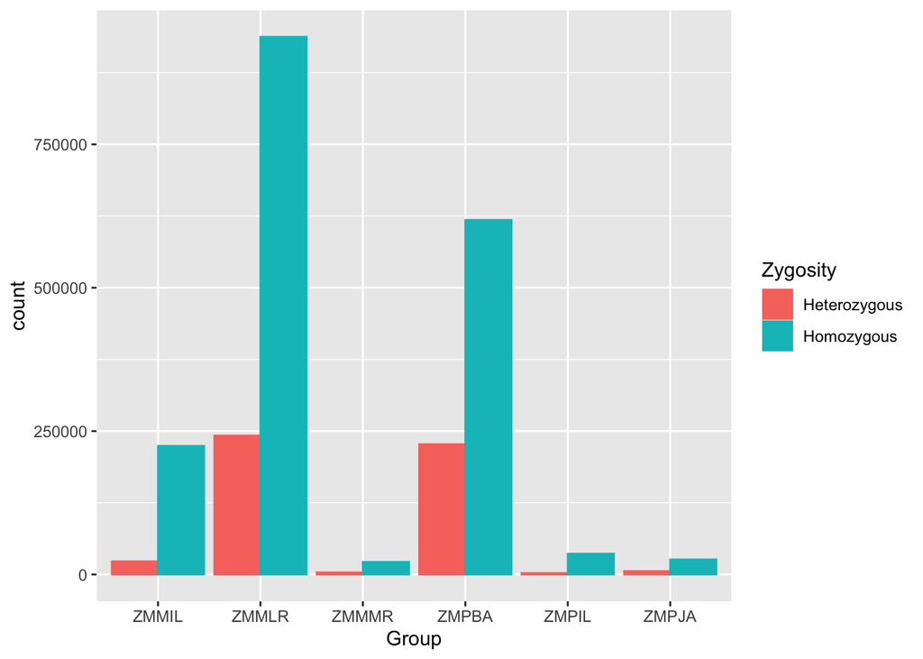

```r
Zy_1 <- filter(Zy_try, Group != "Chromosome")
Zy_2 <- filter(Zy_1, Group != "Position")
ggplot(Zy_2, aes(x=Group, fill= Zygosity, color= Zygosity)) + geom_bar(bins=10, position = "dodge")
```

In the above graph, we can see Zygosity by group.

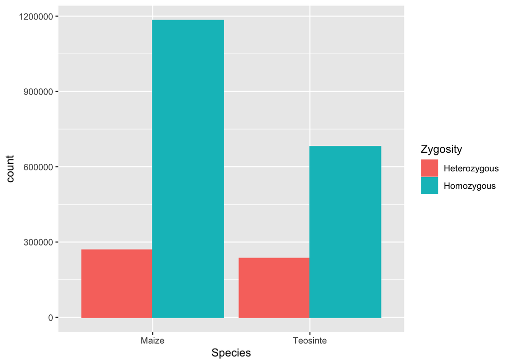

```r
Zy_fun <- Zy_2
Zy_fun$Species = ifelse(Zy_fun$Group %in% c('ZMMLR','ZMMMR','ZMMIL') ,"Maize",
                          ifelse(long_df$NT %in% c('ZMPBA','ZMPIL','ZMPJA'), "Teosinte",
                                 "Teosinte"))
ggplot(Zy_fun, aes(x=Species, fill= Zygosity, color= Zygosity)) + geom_bar(bins=10, position = "dodge")
```

And finally, above see the Zygosity of maize and teosinte, compared. This last graph is my voluntary visualization.